# Visualization

R LAS

December 12, 2016

# R plots

R plot has different methods depending on what the class of the object is.

```r
methods(plot)
```

```
##  [1] plot.acf*           plot.data.frame*    plot.decomposed.ts*
##  [4] plot.default        plot.dendrogram*    plot.density*
##  [7] plot.ecdf           plot.factor*        plot.formula*
## [10] plot.function       plot.hclust*        plot.histogram*
## [13] plot.HoltWinters*   plot.isoreg*        plot.lm*
## [16] plot.medpolish*     plot.mlm*           plot.ppr*
## [19] plot.prcomp*        plot.princomp*      plot.profile.nls*
## [22] plot.raster*        plot.spec*          plot.stepfun
## [25] plot.stl*           plot.table*         plot.ts
## [28] plot.tskernel*      plot.TukeyHSD*
## see '?methods' for accessing help and source code
```

# A Simple Plots

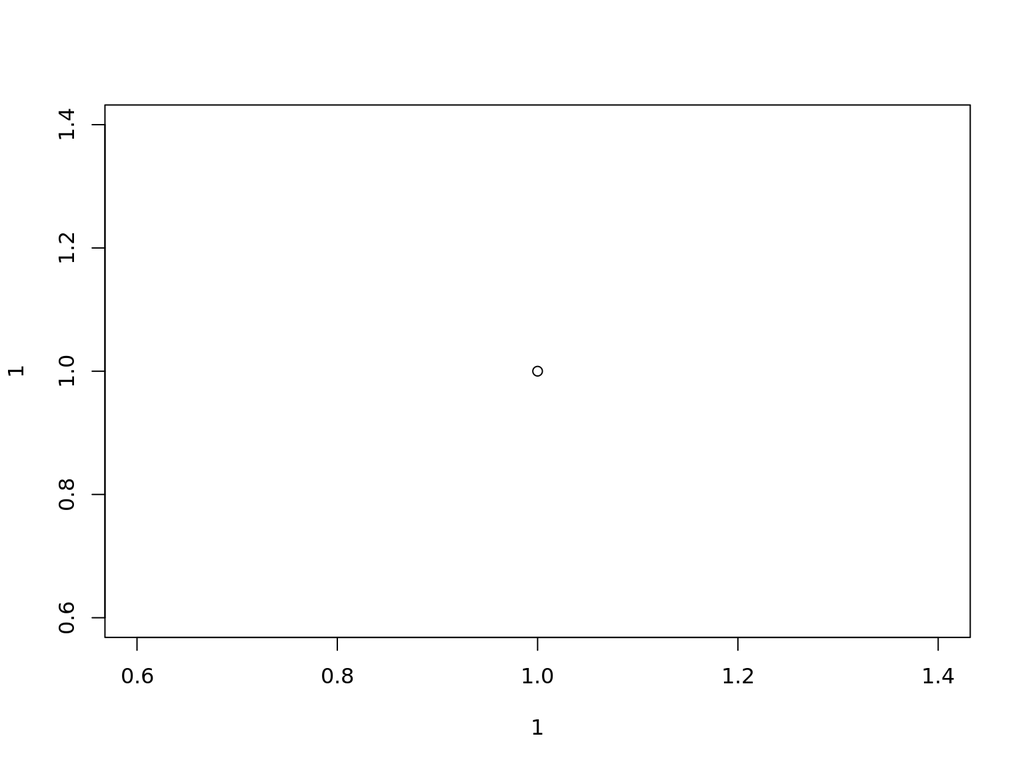

```r
plot(x=1,y=1)
```

Features include:

- Box around plot area
- Point is represented by a circle
- No title or subtitle
- Default axis labels
- Axis limits are determined by data

# Saving Plots

You can save to a pdf, png, and other formats.

```r
pdf(file="samplescatterplot.pdf")
plot(x=runif(100),y=runif(100))
dev.off()
```

```r
getwd()
```

```
## [1] "/home/kevin/raw_las/Rmd"
```

# Plot Options

```r
p1<-par()
dev.off() #close the default device
```

```r
class(p1)
```

```
## [1] "list"
```

```r
length(p1)
```

```
## [1] 72
```

```r
p1[40]
```

```
## $lty
## [1] "solid"
```

# Plot Layout

`layout` divides the device up into as many rows and columns as there are in `matrix`, with the column-widths and the row-heights specified in the respective arguments.

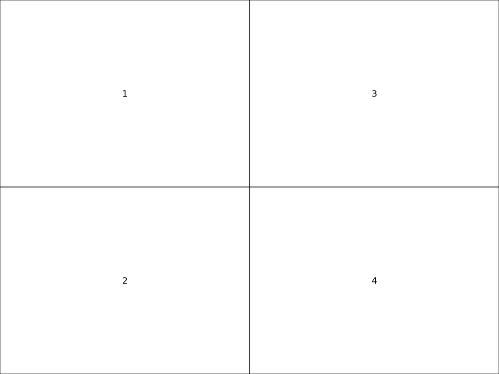

```r
layout(matrix(1:4,nrow=2))
layout.show(4)
```

# Plot Layout

To get a layout, create a matrix representing what you want.

```r
m1<-c(1,2,3,3,3,3)
m1<-
matrix(m1,nrow=2,
  byrow=FALSE)
m1
```

```
##      [,1] [,2] [,3]
## [1,]    1    3    3
## [2,]    2    3    3
```

# Plot Layout

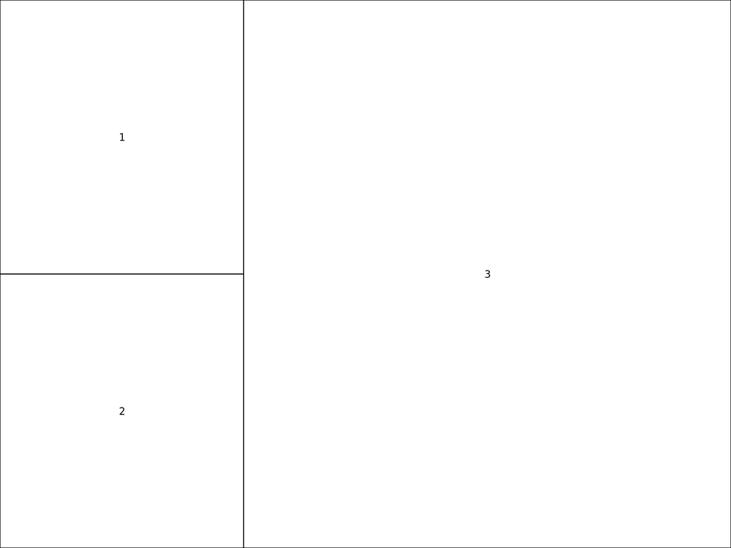

```r
layout(m1)
layout.show(3)
```

# Plot Layout

What commands give the following layout?

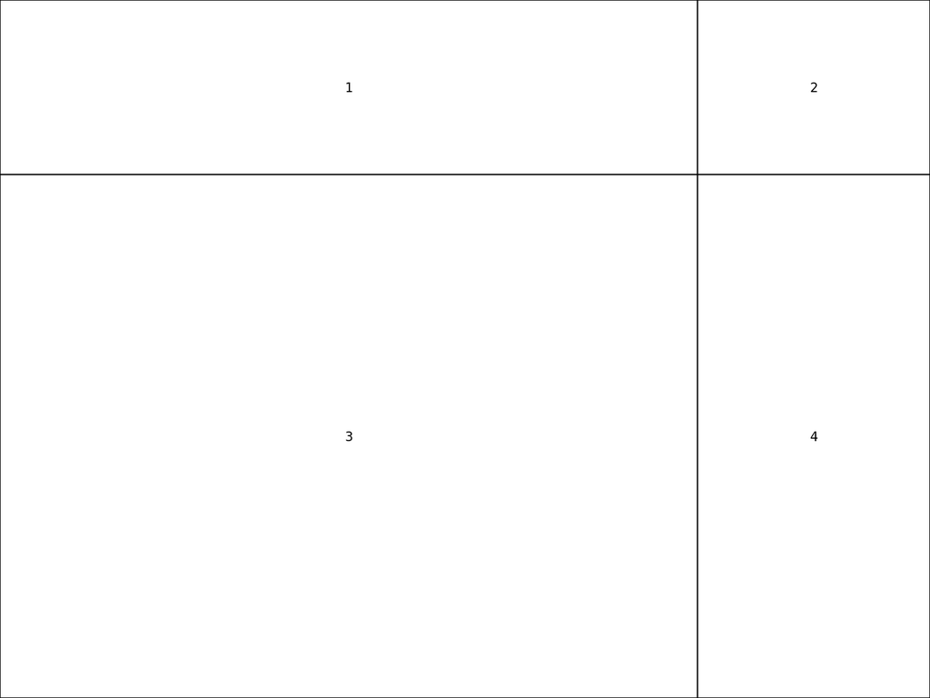

# Plot Layout

Solution.

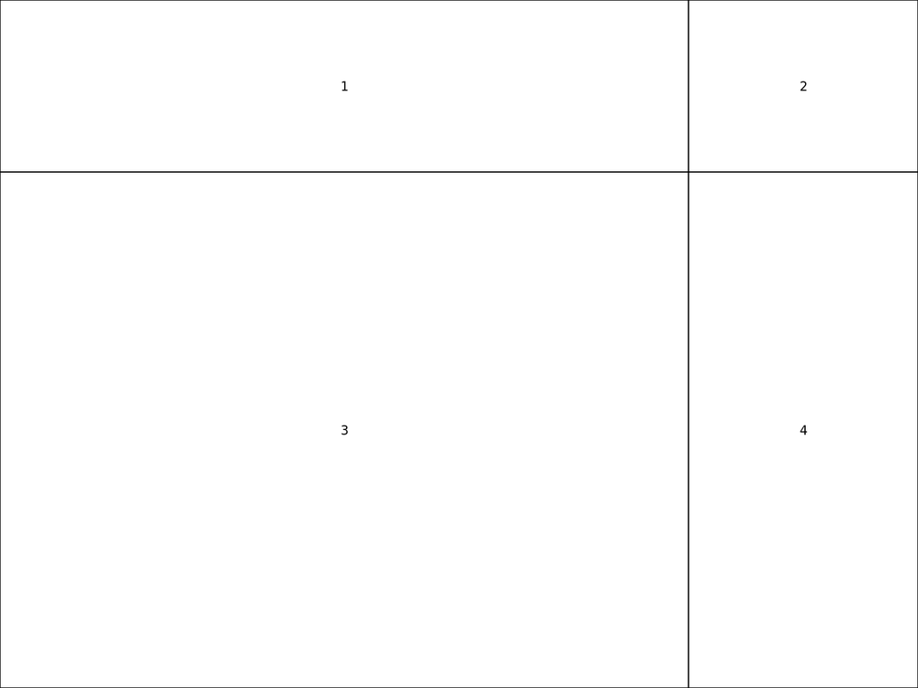

```r
m1<-matrix(c(1,1,1,2,3,3,3,4,3,3,3,4,3,3,3,4),
           nrow=4,byrow=TRUE)
layout(m1)
layout.show(4)
```

# Plot Layout

You can create your own summary plot for exploratory data analysis.

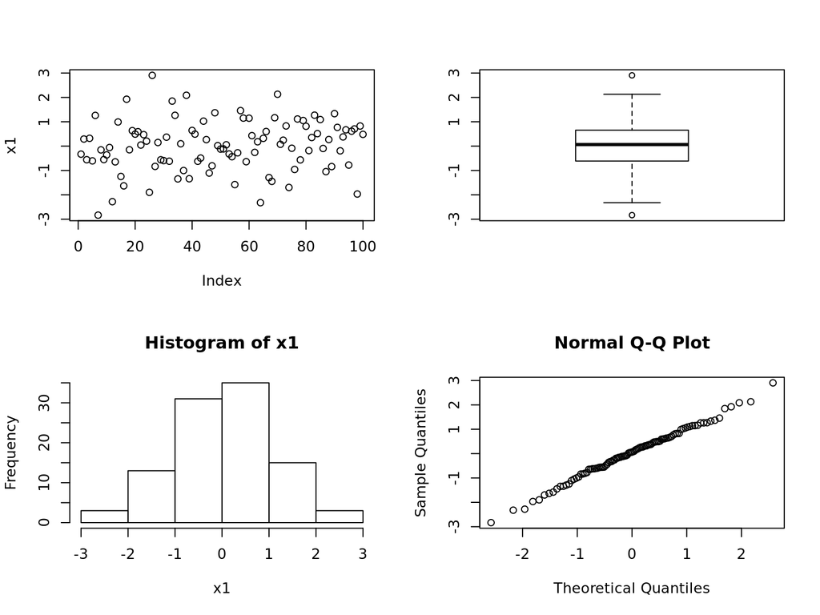

```r
m1<-matrix(1:4,2,2)
x1<-rnorm(100)
layout(m1)

plot(x1)
hist(x1)
boxplot(x1)
qqnorm(x1)
```

# Plot Layout

Let’s write this as a function.

```r
mysummaryPlot<-function(x){
  m1<-matrix(1:4,2)
    layout(m1)
    plot(x)
    hist(x)
    boxplot(x)
    qqnorm(x)
    }
```

# Plot Layout

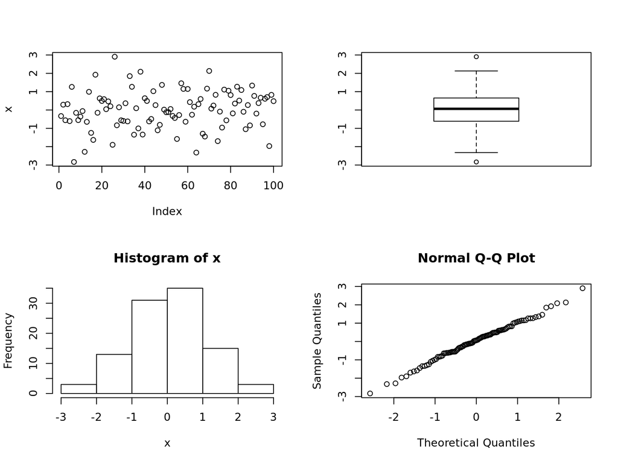

```r
mysummaryPlot(x1)
```

# Colors

There’s a default palette and a large number of colors available.

```r
palette()
```

```
## [1] "black"   "red"     "green3"  "blue"    "cyan"    "magenta" "yellow"
## [8] "gray"
```

```r
length(colors())
```

```
## [1] 657
```

```r
head(colors())
```

```
## [1] "white"         "aliceblue"     "antiquewhite"  "antiquewhite1"
## [5] "antiquewhite2" "antiquewhite3"
```

# Colors

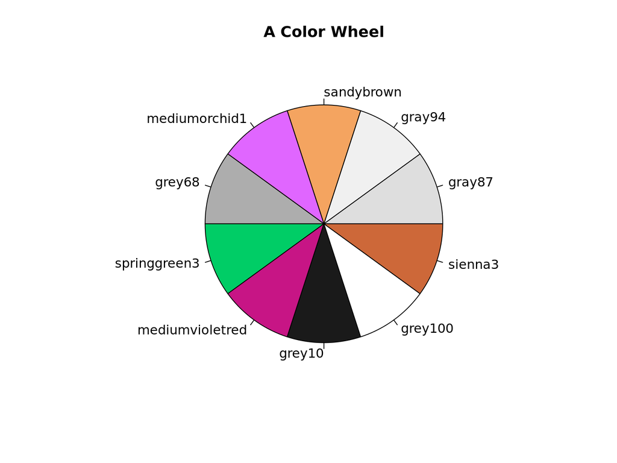

```r
set.seed(6345789)
numColors<-10
n1<-sample(1:length(colors()),replace=FALSE,
           size=numColors)
pie(rep(1,numColors),col=colors()[n1],
    labels=colors()[n1])
title(main="A Color Wheel")
```

# Colors

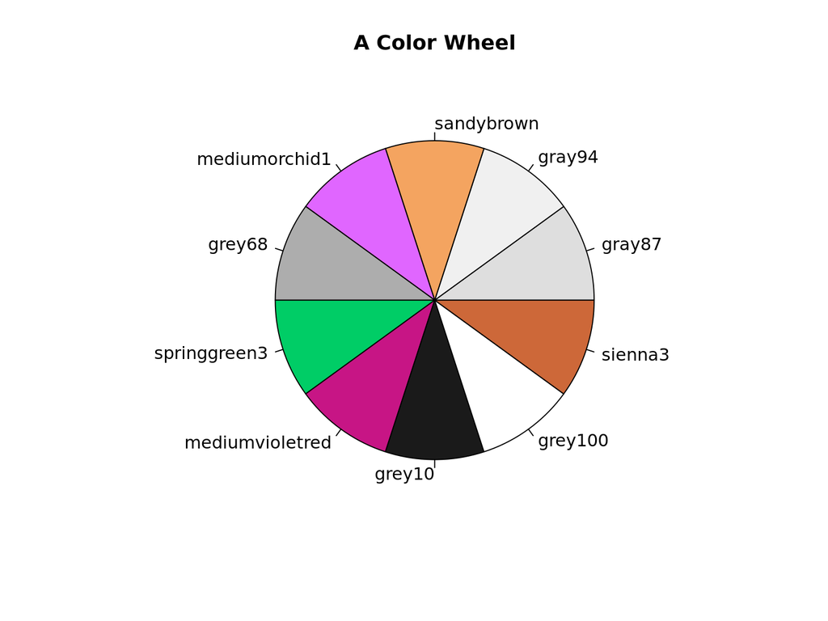

```r
set.seed(6345789)
numColors<-10
n1<-sample(1:length(colors()),replace=FALSE,
           size=numColors)
pie(rep(1,numColors),col=colors()[n1],
    labels=colors()[n1])
title(main="A Color Wheel")
```

# Colors

There are predefined palettes.

- rainbow
- heat.colors
- terrain.colors
- topo.colors
- cm.colors

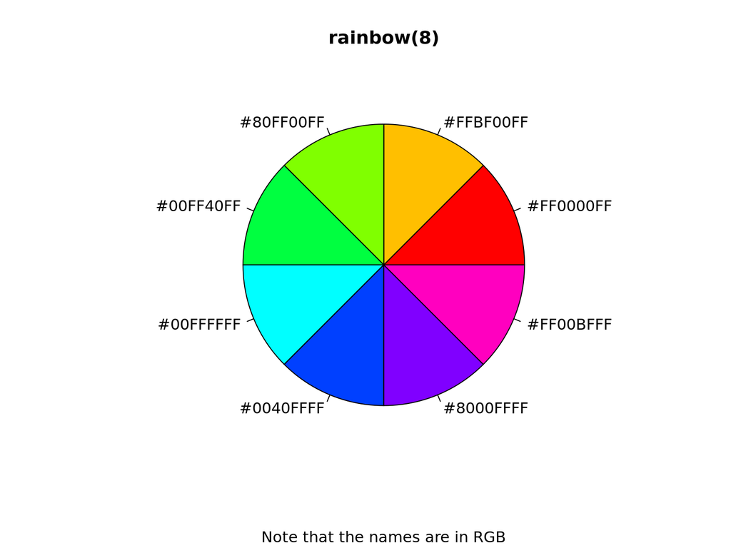

```r
numColors<-8
pie(rep(1,numColors),col=rainbow(numColors),
    labels=rainbow(numColors))
title(main=paste("rainbow(",numColors,")",sep=""))
title(sub="Note that the names are in RGB")
```

# Colors

A very detailed discussion of R colors is available at http://research.stowers-institute.org/efg/R/Color/Chart/

The RColorBrewer package “creates nice looking palettes especially for thematic maps.” http://colorbrewer2.org/

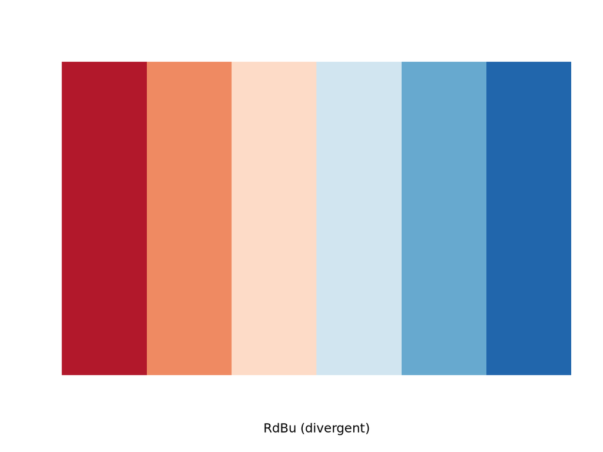

```r
library(RColorBrewer)
display.brewer.pal(6,"RdBu")
```

# pch

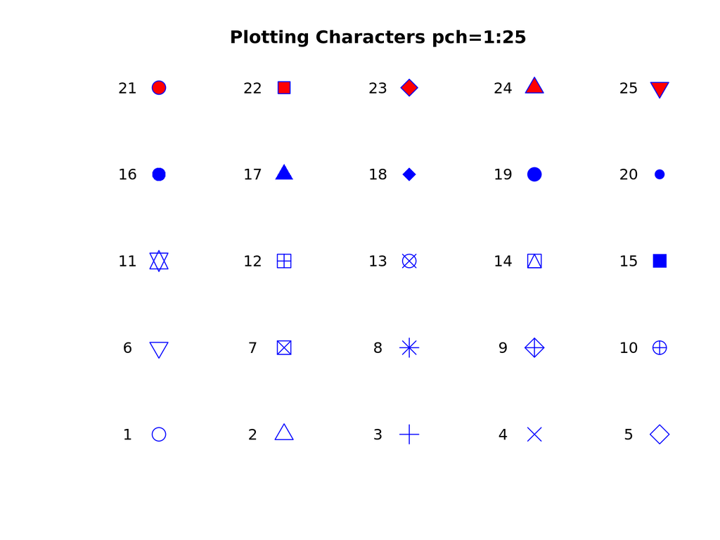

```r
X1<-rep(1:5,5)
Y1<-c(rep(1,5),rep(2,5),rep(3,5),rep(4,5),rep(5,5))
plot(x=X1,y=Y1,pch=1:25,col="blue",bg="red",cex=2,bty="n", xlim=c(0.5,5),
     ann=FALSE,axes=FALSE)
text(x=X1-.25,y=Y1,1:25)
title(main="Plotting Characters pch=1:25")
```

# bty

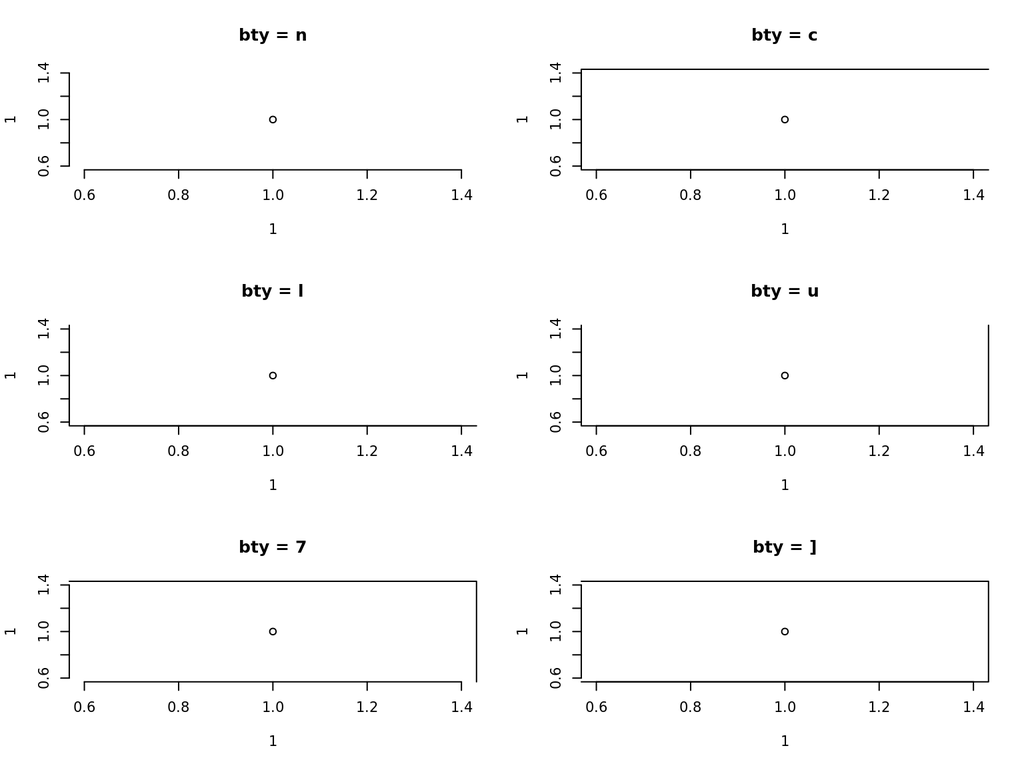

```r
btyopts<-c("n","l","7","c","u","]")
m1<-matrix(1:6,nc=2)
layout(m1)
for (i in 1:6){
plot(x=1,y=1,bty=btyopts[i])
  title(main=paste0('bty = ',btyopts[i]))}
```

# Titles and Axis Labels

`main` and `sub` refer to the main title and subtitle, respectively. Sometimes a plot will have a default title. If you want to supress that you can use`main=NULL` and `sub=NULL`. `xlab` and `ylab` are the x-axis and y-axis labels, respectively.

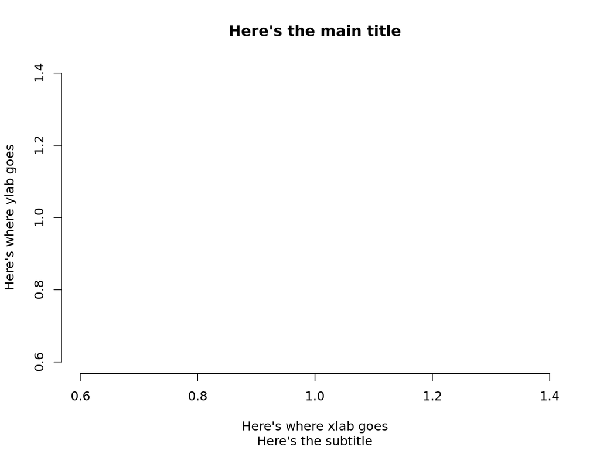

```r
plot(x=1,y=1,xlab="Here's where xlab goes",
  ylab="Here's where ylab goes",type="n",bty="n")
title(main="Here's the main title",sub="Here's the subtitle")
```

# Axes Limits

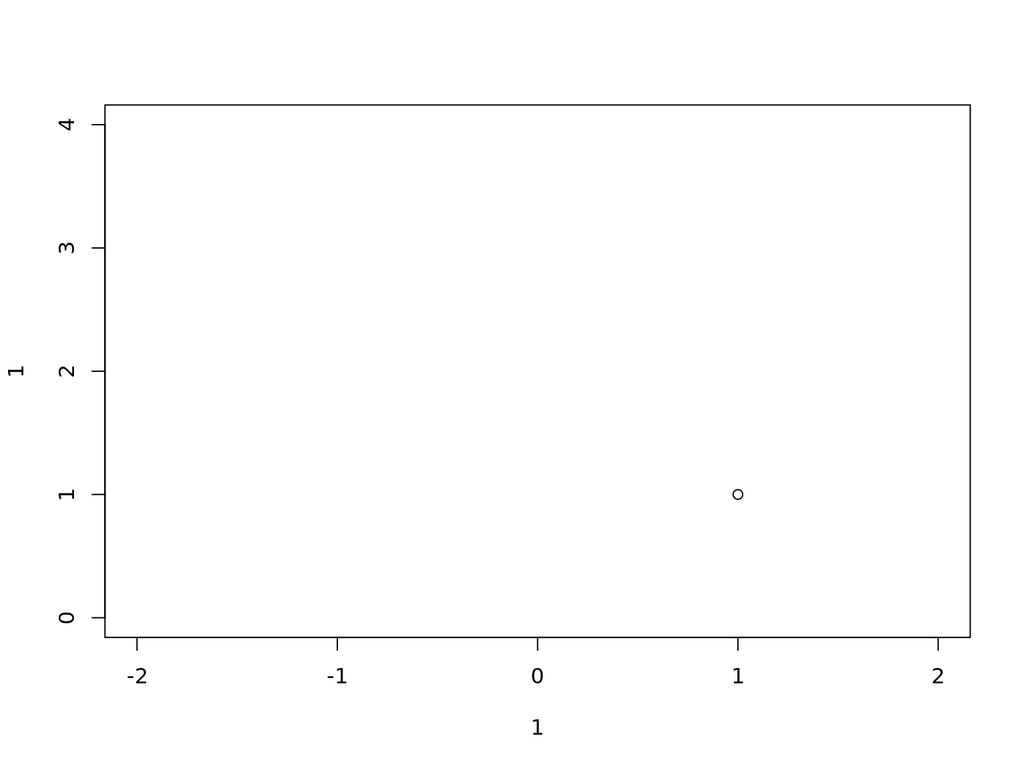

```r
plot(x=1,y=1,
    xlim=c(-2,2),
    ylim=c(0,4)
)
```